# Pacific Giant Salamanders in Mack Creek

Size & Location Analysis

Allison Bailey & Becca Reynolds

11/20/2019

#### **Introduction**

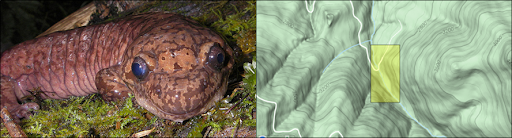

*Figure 1.* Pacific Giant Salamander (*Dicamptodon tenebrosus*) [left] and spatial coverage of the two standard reaches of Mack Creek in the H.J. Andrews Experimental Forest used as survey sites since 1993 [right]. Credit [Oregon Wild](https://oregonwild.org/wildlife/pacific-giant-salamander) and [EDI Data Portal](https://portal.edirepository.org/nis/mapbrowse?scope=knb-lter-and&identifier=4027&revision=12).

#### **Data & Methods**

Pacific Giant Salamander population size and demographics have been examined in Mack Creek, Oregon since 1993, as part of a larger [aquatic vertebrate population study](https://portal.edirepository.org/nis/mapbrowse?scope=knb-lter-and&identifier=4027&revision=12). [1] Areas of focus (reaches) include a section of clear cut forest (CC) and a 500 year-old conifer old growth forest (OG), located upstream of the CC forest. [1] Each reach is approximately 150 m in length, and blocked every 50 m by nets. [1] Samples are taken every 50 m along each reach using 2-pass electrofishing; length and weight data is recorded for all captured aquatic vertebrates. [1] The total number of Pacific Giant Salamanders counted at Mack Creek was visualized to compare abundance in CC forest to that in OG forest. Included is a table displaying Pacific Giant Salamander counts and proportions by channel classification for both OG and CC forests in the year 2017. Based on these values, a Chi-Square test for independence was used to determine if forest condition has a significant effect on the location within the channel at which Pacific Giant Salamanders are found. Additionally, to determine if there is a significant difference in mean weights between the two forest sections, mean Pacific Giant Salamander weights were compared across forest sections using a Welch’s two-sample t-test (alpha = 0.05). Beeswarm plots and quantile-quantile plots were then used to visualize mean weight distributions across each forest section, revealing an abnormal distribution of means. Knowing this, it would have been more accurate to visualize this data using Box-and-whisker plots, and to perform non-parametric statistical analyses to examine sample medians. This report presents analysis and figures exclusively prepared using .R software version 3.6.1.

[figure not shown]

*Figure 2.* Mack Creek is located in the H.J. Andrews Experimental Forest, a Long-Term Ecological Research Site. Credit [GoogleMaps](https://www.google.com/maps/place/Mack+Creek/@44.2331797,-122.1849309,15z/data=!4m5!3m4!1s0x54bf5f54d8de4e19:0xae27a36b0c69a1b8!8m2!3d44.2111833!4d-122.1527863).

#### **Results**

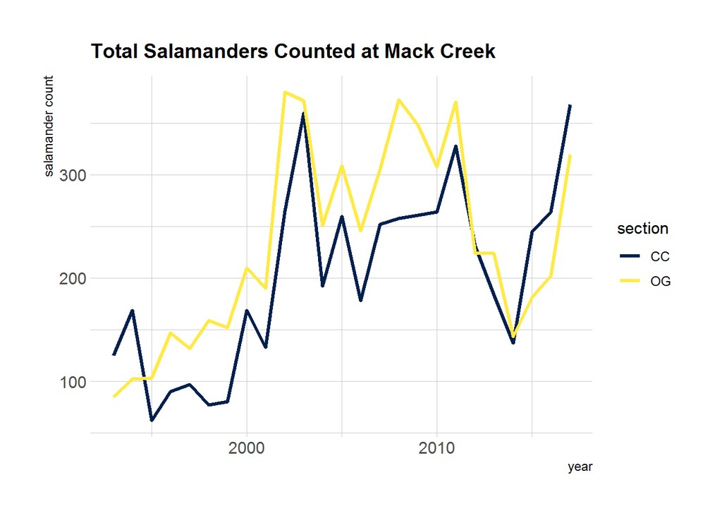

**B.** Table of 2017 salamander counts by channel classification (pool, cascades and side-channel) in old growth (OG) and clear cut (CC) sections of Mack Creek.

**Figure 4.** The table below displays Pacific Giant Salamander counts and proportions by channel classification [pool (P), cascades (C), or side-channel (SC)] in 2017.

| section | C | P | SC |
| --- | --- | --- | --- |
| CC | 247 (67%) | 31 (8%) | 90 (24%) |
| OG | 201 (63%) | 45 (14%) | 74 (23%) |

**C.** 2017 Pacific Giant Salamander counts from the table above were used to determine if there is a significant effect of forest condition on where salamanders are found within the channel based on the channel classifications P, C, and SC. A Chi-Square test for independence revealed that there is *not* a significant association between forest condition and the number of salamanders counted within specific channel classifications ($\chi$<sup>2</sup>(2)) = 5.5412722 and ($p-value$(2)) = 0.0626222.

**D.** A Welch two-sample t-test was used to determine if there is a significant difference in Pacific Giant Salamander mean weights between individuals found in CC or OG forest sections in 2017. Analysis shows that there is *no* significant difference in mean weight of Pacific Giant Salamanders (t(683.21) = 1.4859, p = 0.1378) located in CC forests (7.77587 ± 9.9 g [mean ± sd], n = 368) and OG forests (6.701818 ± 9.035g [mean ± sd], n = 320).

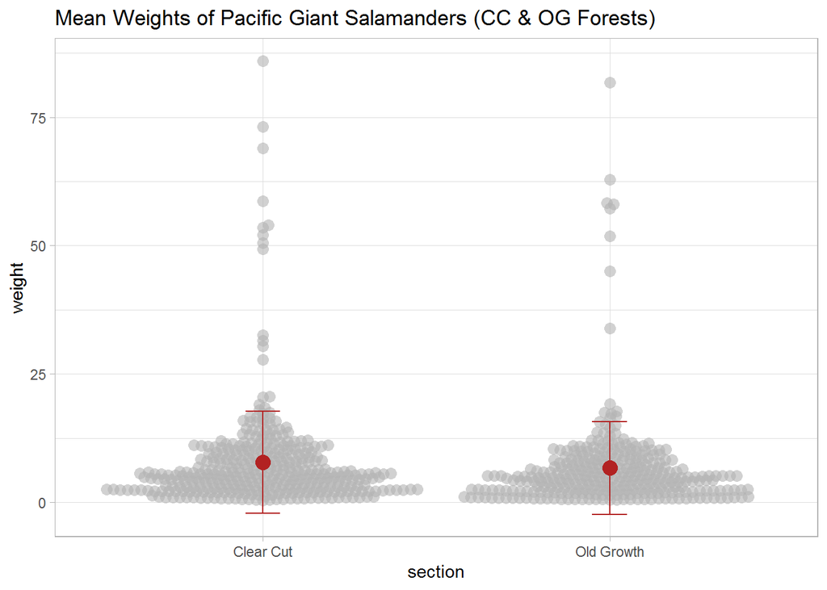

**Figure 5.** Observed Pacific Giant Salamander weights in relation to mean Pacific Giant Salamander weights in OG and CC forests sections.

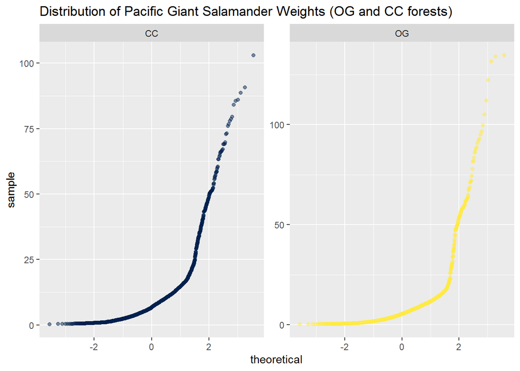

**Figure 6.** This QQ-Plot visualizes the skewed distribution in Pacific Giant Salamander weights in both OG and CC forest sections.

A Quantile-quantile plot was created to determine if Pacific Giant Salamander weight data is normally distributed. Based on the results of this plot, it is evident that the Salamander weight data is *not* normally distributed in either forest section. Therefore, analyzing this data based on mean values likely produced inaccurate outcomes. To avoid errors due to skewed data, statistical analyses should have focused on median Salamander weights. Using a non-parametric Wilcox Test and visualizing the data through a boxplot would have produced more accurate outcomes.

| unittype | mean_weight | sd_weight | sample_size | se_weight | var_weight |
| --- | --- | --- | --- | --- | --- |
| C | 7.520850 | 9.027747 | 448 | 0.4265209 | 81.50021 |
| P | 9.297500 | 13.622957 | 76 | 1.5626603 | 185.58494 |
| SC | 5.676646 | 8.265256 | 164 | 0.6454081 | 68.31446 |

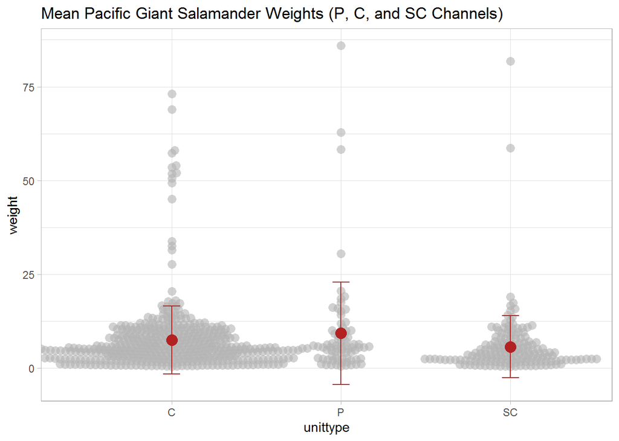

**Figure 8.** The beeswarm plot above visualizes the mean Pacific Giant Salamander weights in each of the different channels (P, C, and SC).

**E.** Mean Pacific Giant Salamander weights did *not* differ significantly between Pool (9.29 +/- 1.56) and Cascades (7.52 +/- 0.43) nor did it differ significantly between the Cascades and the Side Channel (5.68 +/- 0.65). However, there *is* a significant difference between Salamander weights when comparing individuals found in the Side Channel to those found in Pool channel classifications (one-way ANOVA with post-hoc Tukey’s HSD, F(2) = 4.2156, SC-P *p adj* < 0.05). However, after running the difference against a Cohen’s d test and receiving a value of approximately 0.352 it can be concluded that the difference in mean Salamander weight between Pool and Side Channel classifications is small.

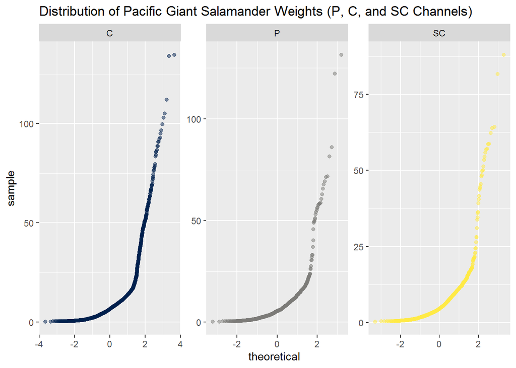

**Figure 9.** The above QQ-Plot visualizes the skewed distribution of Pacific Giant Salamander weights in each of the different channels (P, C, and SC).

Again, it is important to note that the mean Pacific Giant Salamander weight measurements are not normally distributed within each sample. Performing statistical analyses using the mean Salamander weight has likely produced skewed test results. Comparing the median Salamander weights by running non-parametric Wilcox Tests and visualizing the data using boxplots would have provided more accurate outcomes.

#### **Summary**

- When visualized, changes in Pacific Giant Salamander counts over time displayed similar trends across OG and CC forest sites in Mack Creek.
- A Chi-Square test for independence revealed that there is *not* a significant association between forest condition and the number of salamanders counted within specific channel classifications.
- Measurements of Pacific Giant Salamander weights in OG and CC forests, as well as measurements of Salamander weights in P, C, and SC sites, *did not display normal distributions*.
- Analyses show that there is *no* significant difference in mean weight of Pacific Giant Salamanders between OG and CC sites, nor is there a significant difference in Salamander mean weight across P and C, and C and SC sites. There is a small difference in mean Salamander weight between P and SC sites.
- Mean Pacific Giant Salamander weight measurements are *not* normally distributed within each sample. Performing statistical analyses using median Salamander weights would produce more accurate results.

#### **References**

[1]Andrews Forest LTER Site and S. V. Gregory, “Aquatic Vertebrate Population Study in Mack Creek, Andrews Experimental Forest, 1987 to present.” Environmental Data Initiative, 2016.

[2]“Pacific Giant Salamander | Oregon Wild.” [Online]. Available: https://oregonwild.org/wildlife/pacific-giant-salamander. [Accessed: 30-Nov-2019].

[3]“The IUCN Red List of Threatened Species,” IUCN Red List of Threatened Species. [Online]. Available: https://www.iucnredlist.org/en. [Accessed: 01-Dec-2019].